# Aplicação da função W de Lambert para o cálculo do limite técnico

Ismael Bastos

# 1 Função Inversa

Para entender a função W de Lambert, primeiramente precisamos compreender o conceito de função inversa.

Seja uma função $f: A \rightarrow B$, podemos definir uma função $f^{-1}: B \rightarrow A$ a qual chamaremos de função inversa de $f$.

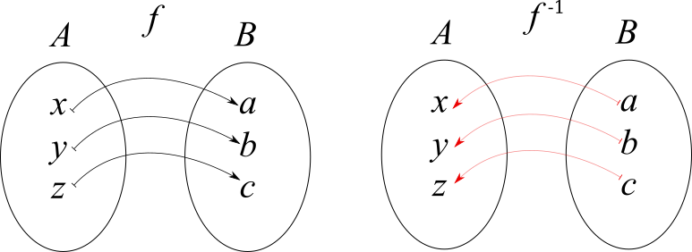

Basicamente, $f^{-1}$ desfaz o que $f$ cria. É importante ressaltar que estamos admitindo a existência da função inversa, no entanto, nem sempre isso é possível. Por exemplo, seja $f: A \rightarrow B$, em que $f(x)$ é representada através da imagem abaixo.

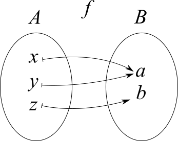

Temos que, $f(x) = f(y) = a$, no entanto, $f^{-1}(a)$ não pode ser simultaneamente $x$ e $y$, pois não é permitido que existam ambiguidades, trata-se de um absurdo. Analisando $f$, é notório que trata-se de uma função não-injetiva, com isso, é possível chegar a conclusão que se a função não for injetiva, então não é possível obter sua inversa.

Ainda nesse sentido, poderíamos ter a seguinte situação: Seja $f: A \rightarrow B$, em que $f(x)$ é representada através do esquema abaixo.

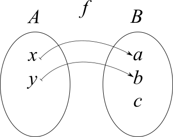

É possível perceber que $c \in B$, mas não existe $f^{-1}(c)$, portanto, nesse caso também não existe $f^{-1}$, ou seja, $f$ não possui inversa, pois, pela definição de função, não podem haver exceções em relação ao seu domínio. Podemos extrapolar essa noção e afirmar que, sempre que tivermos uma função que não é sobrejetiva, então ela não possuirá inversa.

Com isso, é possível estabelecer dois critérios para que uma função possua inversa:

- A função é injetiva
- A função é sobrejetiva

Se uma função é injetiva e sobrejetiva, então ela é bijetiva, o que nos leva a seguinte conclusão.

**Uma função só admite inversa caso seja bijetiva.**

**Exemplo $1.1$:** Seja $f: \mathbb{R} \rightarrow \mathbb{R}$ tal que $f(x) = e^x$, determine $f^{-1}$.

$f$ é injetiva, se $\forall \ x_1, x_2 \in \mathbb{R}$ temos que $f(x_1) = f(x_2) \implies x_1 = x_2$

$$\begin{gather*}
f(x_1) = e^{x_1}\\
f(x_2) = e^{x_2}
\end{gather*}$$

$$\begin{align*}
f(x_1) &= f(x_2)\\
e^{x_1} &= e^{x^2}\\
ln(e^{x_1}) &= ln(e^{x_1})\\
x_1 &= x_2
\end{align*}$$

Com isso, demonstramos que f é injetiva. Para demonstrar que é sobrejetiva temos que demonstrar que:
$$\begin{equation}
\forall y \in \mathbb{R}, \exists x \in \mathbb{R}, \text{ tal que } f(x) = y.
\end{equation}$$

$$\begin{gather*}
y = e^x\\
x = ln(y)\\
\end{gather*}$$

$$\begin{align*}
f(x) &= f(ln(y))\\
&= e^{ln(y)}\\
&= y
\end{align*}$$

Logo, $f$ é bijetiva e, portanto, admite inversa.

Admitindo $f(x) = y$, para obter $f^{-1}$, basta trocar $x$ por $y$

$$\begin{gather*}
y = e^x\\
x = e^y\\
y = ln(x)
\end{gather*}$$

Portanto, podemos afirmar que $f^{-1}: \mathbb{R} \rightarrow \mathbb{R}$ é definida por $f^{-1}(x) =ln(x)$.

**Exemplo $1.2$:** Seja $f: \mathbb{R} \rightarrow \mathbb{R}$ tal que $f(x) = x^2$, determine $f^{-1}$.

Uma forma bem simples de verificar se $f$ é injetiva é realizar o teste da reta horizontal, que consiste em traçar uma reta horizontal no gráfico da função análisada.

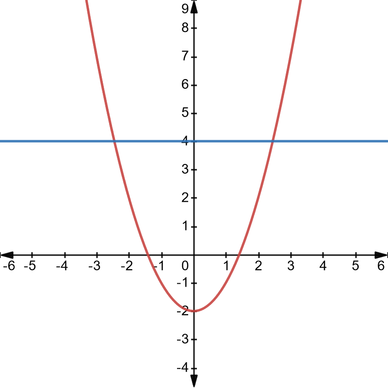

Como a reta horizontal toca a função em dois pontos distintos, a função não é injetiva. Da mesma forma, é possível verificar que $f(-2)=f(2) =4$, de forma geral, $f(x) = f(-x) = x^2$. Como $f$ não é injetiva, segue que também não é bijetiva e portanto não possui inversa.

Entretanto, se alterarmos o domínio de $f$, podemos fazer com que ela possua inversa. Vamos considerar agora o seguinte problema: Seja $f: \mathbb{R^+} \rightarrow [-2, \infty)$ de forma que $f(x) = x^2$, determine $f^{-1}$.

Realizando novamente o teste da reta horizontal, é possível verificar que a reta toca em apenas um ponto. A reta $y=4$ foi escolhida de forma arbitrária, mas é possível notar que qualquer outra reta horizontal $y=h$ com $h \in [-2, \infty)$ toca em apenas um ponto da mesma maneira.

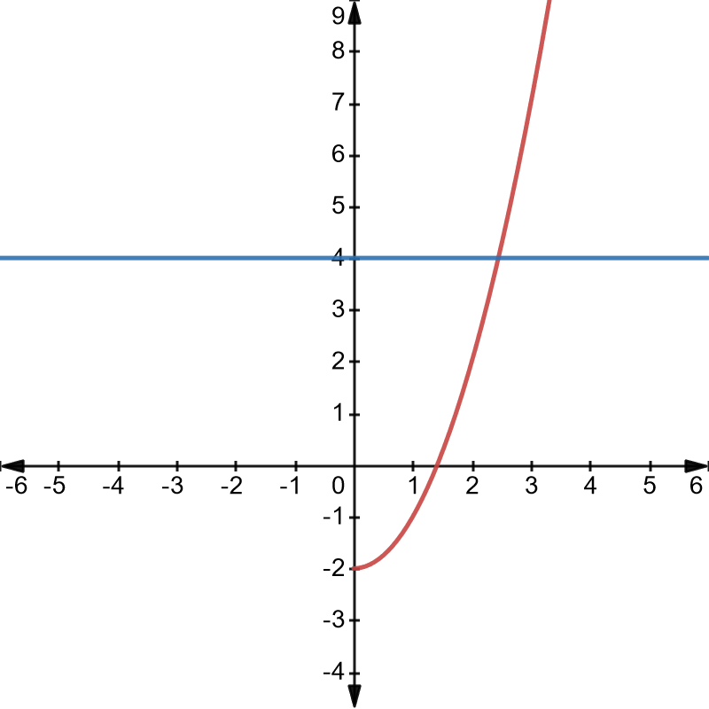

De forma analítica, é possível demonstrar que $f$ é injetiva:

Seja $x_1, x_2\ \in \mathbb{R^+}$, então
$$\begin{gather*}
f(x_1) = x_1^2\\
f(x_2) = x_2^2
\end{gather*}$$

$$\begin{align*}
f(x_1) &= f(x_2)\\
x_1^2 &= x_2^2\\
\sqrt{x_1^2} &= \sqrt{x_2^2}\\
x_1 &= x_2
\end{align*}$$

portanto, $f$ é injetiva.

Para verificar que é sobrejetiva basta perceber que

$$\begin{align*}
y &= x^2\\
x &= \sqrt{y}\\
f(\sqrt{y}) &= \sqrt{y}^2\\
f(\sqrt{y}) &= y\\
\end{align*}$$

Logo, $f$ é bijetiva e, portanto, possui inversa dada pela seguinte expressão

$$\begin{align*}
y &= x^2\\
x &= y^2\\
y &= \sqrt{x}.
\end{align*}$$

Podemos afirmar que $f^{-1}: [-2, \infty) \rightarrow \mathbb{R^+}$ é definida por $f^{-1}(x) =\sqrt{x}$.

Um raciocínio análogo poderia ser feito para $f: \mathbb{R^-} \rightarrow [-2, \infty)$.

# 2 Função W de Lambert

Começaremos nosso estudo através da função $f: \mathbb{R} \rightarrow \mathbb{R}$, definida por $f(x) = xe^x$

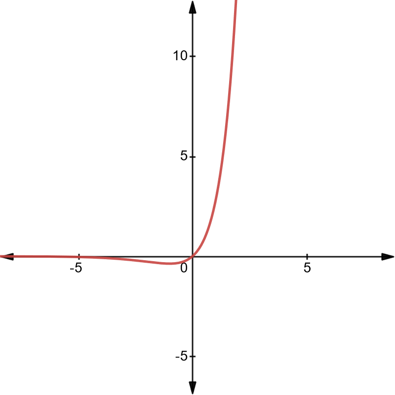

Pela visualização de seu gráfico, é evidente que trata-se de uma função não-injetiva, portanto, não possui inversa, podendo ser esse fato verificado facilmente pelo teste da reta horizontal.

Portanto, $f$ não é bijetiva. No entanto, assim como ocorre para a função $f(x) = x^2$, é possível delimitar seu domínio e obter funções inversíveis, no caso de $f(x) = xe^x$, podemos realizar uma abordagem semelhante.

É possível verificar, através da primeira derivada de $f$, que $x=-1$ é um mínimo global e que $f'(x)>0,\quad x>-1$. Da mesma forma $f'(x)<0,\quad x<-1$.

Logo, é possível notar que $f: [-1, \infty) \rightarrow [-1/e, \infty)$ tal que $f(x) = xe^x$ é injetiva. Assim como $g: (-\infty, -1] \rightarrow (-1/e, 0]$ com $g(x)= xe^x$ também é injetiva.

Ademais, é possível verificar que $f$ e $g$ são sobrejetivas, utilizando-se para isso, o teorema do valor médio.

Por fim, sabemos que $f$ e $g$ são bijetivas e, portanto, possuem inversa, desse modo, ambas são bijetivas e, portanto, inversíveis.

A inversa de $f$ é denotada por $W_{0}$ e é chamada de função $W$ de Lambert no ramo $0$. De forma semelhante, a inversa de $g$ é denotada por $W_{-1}$ e é denominada função $W$ de Lambert no ramo $-1$.

O gráfico abaixo apresenta a função $W$ de lambert nos ramos $-1$ e $0$, assim como as funções $f$ e $g$:

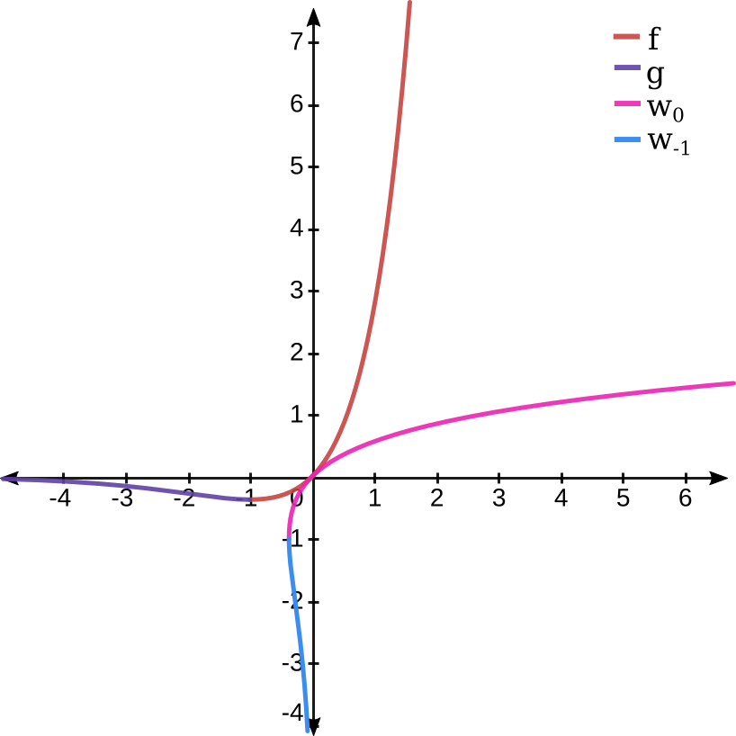

# 3 Calcular a função W de Lambert em um ponto

Para explicar como avaliar a função W de lambert em um ponto específico, partiremos do seguinte exemplo.

**Exemplo $3.1$:** Determine $x$ que satisfaça a seguinte equação:
$$\begin{equation}
2^x = 10x
\end{equation}$$

Para resolver esse problema, podemos realizar os seguintes passos:
$$\begin{align*}
ln(2^x) &= ln(10x )\\
xln(2) &= ln(10x)\\
e^{xln(2)} &= 10x\\
xe^{-xln(2)} &= \dfrac{1}{10}\\
-x\ln{(2)}e^{-xln(2)} &= -\dfrac{\ln{(2)}}{10}
\end{align*}$$

Nesse ponto, é possível verificar o surgimento da expressão : $-x\ln{(2)}e^{-xln(2)}$.

Um ponto importante sobre inversas é que:

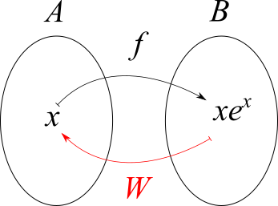

Logo, temos a seguinte identidade:

$$\begin{equation}
\tag{P.1}
\label{eq:"P1"}
W(xe^x) = x
\end{equation}$$

Através da propriedade enunciada acima, conseguimos realizar mais um passo do **Exemplo $3.1$**. Tinhamos que:

$$\begin{equation}
-x\ln{(2)}e^{-xln(2)} = -\dfrac{\ln{(2)}}{10},
\end{equation}$$
aplicando $P.1$, segue que:

$$\begin{align}
W(-x\ln{(2)}e^{-xln(2)}) = W\Bigg(-\dfrac{\ln{(2)}}{10}\Bigg)\\
-\ln{(2)}x = W\Bigg(-\dfrac{\ln{(2)}}{10}\Bigg)\\
x = W\Bigg(-\dfrac{\ln{(2)}}{10}\Bigg) \cdot -\dfrac{1}{\ln{(2)}}
\end{align}$$

A partir de agora, surgem ose seguintes questionamentos:

- Em qual ramo vamos calcular a função $W$ de Lambert?
- Como calcular numericamente $W\Bigg(-\dfrac{\ln{(2)}}{10}\Bigg)$ ?

Como resposta a primeira pergunta, basta anlisar o valor que está sendo avaliado na função, no caso do **Exemplo $3.1$**, $-\dfrac{\ln{(2)}}{10}$. Como $-\dfrac{\ln{(2)}}{10} \in [-1/e, 0]$ então é possível calcular a função $W$ de Lambert em ambos os ramos. É importante notar que isso foi possível nesse exemplo, mas nem sempre será possível avaliar nos dois ramos. Com efeito, é possível verificar que caso $x>0$, só é possível calcular a função $W$ de Lambert no ramo $0$.

Como resposta para a segunda pergunta, é possível afirmar que não se pode obter, analiticamente, o valor exato da função. Portanto, iremos recorrer a aproximação pelo metódo de **Newton-Raphson** para obtenção de raízes de funções reais.

# 4 Método de Newton-Raphson

O método de Newton-Raphson é um método iterativo para encontrar raízes de funções reais. O método consiste em selecionar um ponto inicial, em seguida calcular a intersecção entre a reta tangente a esse ponto e o eixo das abscissas, em seguida é obtida a imagem da função nesse ponto e novamente calculada a reta tangente e sua intersecção com o eixo das abscissas. Esse processo é repetido até que a diferença entre o ponto de intersecção de duas sucessivas retas tangentes seja inferior a um dado valor $\epsilon$.

Começando com um exemplo simples:

**Exemplo $4.1$:** Utilizando o método de Newton-Raphson, encontre uma aproximação para o valor de $\sqrt{2}$.

Podemos nos valer da função $f: \mathbb{R} \rightarrow \mathbb{R}$ definida por $f(x) = x^2 -2$, já que possui como raízes reais os valores $\sqrt{2}$ e $-\sqrt{2}$.

Como o objetivo do método é encontrar raízes reais de funções, nesse ponto, podemos aplicá-lo na função $f(x) = x^2 -2$ para encontrar uma aproximação para o valor de $\sqrt{2}$.

O primeiro passo é definir um ponto inicial, como já sabemos que $\sqrt{2}$ é uma raiz da função, começaremos por um ponto a sua direita, no caso definaremos arbitrariamente o valor $x=4$.

Como mencionado anteriormente, o primeiro passo é encontrar a reta tangente ao ponto $(4,14)$. Essa tarefa se torna simples, uma vez que temos um ponto pertencente a reta e a inclicação da reta pode ser obtida através da derivada de primeira ordem de $f$.

$$f'(x) = 2x$$

Logo, a reta tangente ao ponto $(4,14)$ é obtida da seguinte forma:

$$\begin{align}
g(x) - 14 &= 8(x - 4) \\
g(x) &= 8x - 18
\end{align}$$

O próximo passo é encontrar a intersecção entre a reta tangente e o eixo $x$, ou seja, $g(x)=0$.

$$\begin{align}
8x-18 &=0\\
x &= \dfrac{18}{8}\\
x &= 2,25
\end{align}$$

Novamente, iremos determinar a reta tangente ao ponto $(2,25, 3,0625)$
$$\begin{align}
g(x) - 3,0625 &= 4,5(x - 2,25) \\
g(x) &= 4,5x - 7,0625
\end{align}$$

Em seguida, basta calcular a intersecção entre a reta tangente e o eixo $x$.

$$\begin{align}
4,5x - 7,0625 &=0\\
x &= \dfrac{7,0625}{4,5}\\
x &= 1,57
\end{align}$$

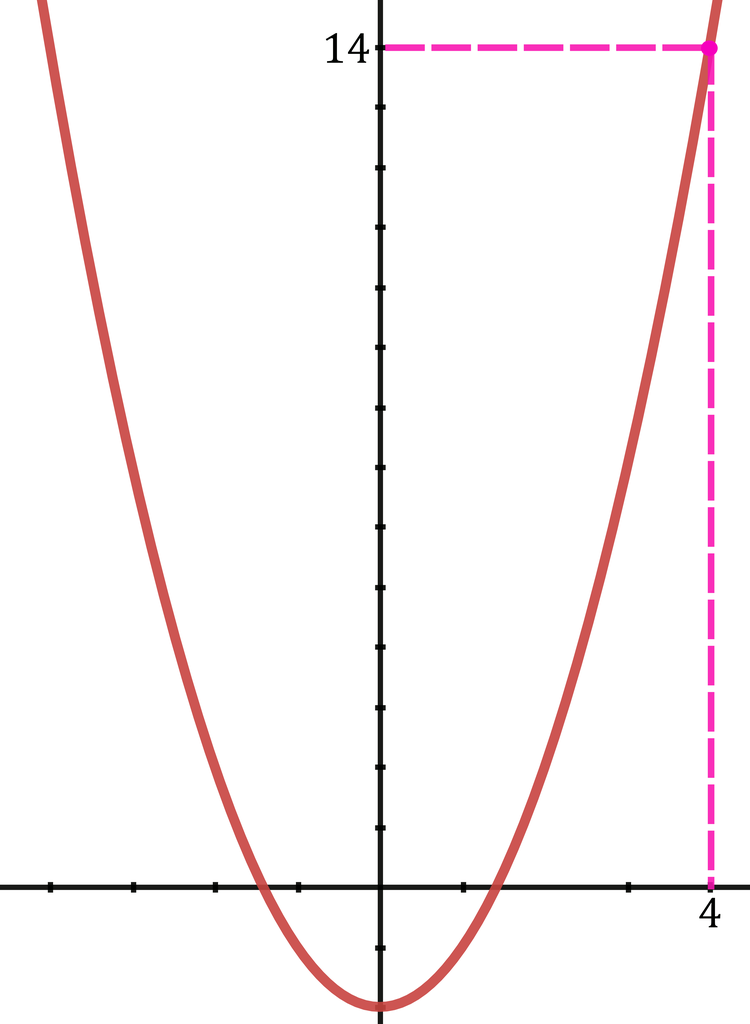

Resumidamente, o método consiste em:

1. Determinar um ponto inicial de maneira arbitrária, também comumente conhecido informalmente como chute inicial.
2. Determinar a reta tangente a esse ponto.
3. Encontrar o ponto de intersecção entre a reta tangente o eixo $x$.
4. Atualizar o ponto inicial com o ponto encontrado no passo anterior.

A partir disso, se torna simples estabelecer uma relação recursiva que resuma o processo descrito acima.

Denotando por $g(x)$ a equação da reta tangente, sabemos que:

$$\begin{gather*}
g(x) - f(x_0) = f'(x_0)(x - x_0)
\end{gather*}$$

Sabemos que um ponto pertencente a essa reta é $(x_1, 0)$, que é exatamente o ponto de intersecção da reta tangente com o eixo $x$, portanto,

$$\begin{gather*}
0 - f(x_0) = f'(x_0)(x_1 - x_0)\\
x_1 = x0 - \dfrac{f(x_0)}{f'(x_0)}
\end{gather*}$$

Podemos generalizar a expressão acima para qualquer valor $n \in \mathbb{N^*}$

$$\begin{equation}
x_n = x_{n-1} - \dfrac{f(x_{n-1})}{f'(x_{n-1})}
\end{equation}$$

É possível transformar a equação acima em código também recursivo. No presente texto será utilizada a linguagem **R**

```r
library(numDeriv)

nr <- function(x0, f, i){
  if(i == 0) return(x0)
  return(nr(x0, f, i-1) -f(nr(x0, f, i-1))/grad(f, nr(x0, f, i-1)))
}
```

em que $x0$ é o chute inicial, $f$ a função na qual desejamos encontrar a raiz e $i$ o número de iterações.

Utilizando o código criado, é possível verificar que

```r
f <- function(x) return(x^2-2)
```

```r
print(nr(4, f, 1))
```

```
## [1] 2.25
```

É possível verificar que o resultado é igual ao obtido de forma manual, sendo possível verificar também para o caso de duas iterações

```r
print(nr(4,f,2))
```

```
## [1] 1.569444
```

De forma amnual, acaba sendo cansativo realizar muitas iterações, mas com o auxílio do computador é possível analisar o comportamento dos resultados obtidos de acordo com o numero de iterações. No código abaixo é apresentado o resultado com o número de iterações variando entre 1 e 10.

```r
for(i in seq(1,10)){
  cat("Número de Iterações",i," Resultado:", nr(4,f,i), "\n")
}
```

```
## Número de Iterações 1  Resultado: 2.25
## Número de Iterações 2  Resultado: 1.569444
## Número de Iterações 3  Resultado: 1.42189
## Número de Iterações 4  Resultado: 1.414234
## Número de Iterações 5  Resultado: 1.414214
## Número de Iterações 6  Resultado: 1.414214
## Número de Iterações 7  Resultado: 1.414214
## Número de Iterações 8  Resultado: 1.414214
## Número de Iterações 9  Resultado: 1.414214
## Número de Iterações 10  Resultado: 1.414214
```

O método de Newton-Raphson será de grande utilidade para o uso da função $W$ de Lambert, assim como será visto a seguir.

# 5 Utilização do método de Newton-Raphson para aproximação da função W de Lambert

Retomando a segunda pergunta feita no **Exemplo $3.1$**.

- Como calcular numericamente $W\Bigg(-\dfrac{\ln{(2)}}{10}\Bigg)$ ?

Já sabemos que teremos valores diferentes para cada um dos ramos da função $W$ de Lambert, vamos começar pelo ramo $-1$.

É possível verificar que

$$\begin{gather*}
y = W_{-1}\Bigg(-\dfrac{\ln{(2)}}{10}\Bigg)\\
ye^y = -\dfrac{\ln{(2)}}{10}\\
ye^y + \dfrac{\ln{(2)}}{10} = 0
\end{gather*}$$

Ou seja, definindo $f(y) = ye^y + \dfrac{\ln{(2)}}{10}$, o problema se resume a encontrar a raiz real de $f(y)$, para isso,podemos nos valer do método de Newton-Raphson.

Uma dúvida que surge é qual chute inicial devemos utilizar. Como estamos calculando uma aproximação no ramo $-1$, sabemos que o chute-inicial $y_0$ deve se encontrar no intervalo $(-\infty, -1)$, portanto, vamos escolher, arbitrariamente, o valor $y_0=-2$.

$$\begin{align*}
x_1 &= x_0 - \dfrac{f(x_0)}{f'(x_0)}\\
&= -2 - \dfrac{-2e^{-2} + \frac{ln(2)}{10}}{e^{-2} -2e^{-2}}\\
&= -3,4878\\
x_2 &= x_1 - \dfrac{f(x_1)}{f'(x_1)}\\
&= -3,4878 - \dfrac{-3,4878e^{-3,4878} + \frac{ln(2)}{10}}{e^{-3,4878} -3,4878e^{-3,4878}}\\
&= -3,9783\\
x_3 &= x_2 - \dfrac{f(x_2)}{f'(x_2)}\\
&= -3,9783- \dfrac{-3,9783e^{-3,9783} + \frac{ln(2)}{10}}{e^{-3,9783} -3,9783e^{-3,9783}}\\
&= -4,0707
\end{align*}$$

Utilizando a função criada anterioremente, podemos obter os mesmos valores, além de ser possível realizar maior número de iterações.

```r
f <- function(y) return(y*exp(y) + log(2)/10)
for(i in seq(1,10)) cat("Número de Iterações:",i," ", nr(-2, f, i),"\n")
```

```
## Número de Iterações: 1   -3.48783
## Número de Iterações: 2   -3.9783
## Número de Iterações: 3   -4.070662
## Número de Iterações: 4   -4.07363
## Número de Iterações: 5   -4.073633
## Número de Iterações: 6   -4.073633
## Número de Iterações: 7   -4.073633
## Número de Iterações: 8   -4.073633
## Número de Iterações: 9   -4.073633
## Número de Iterações: 10   -4.073633
```

Nesse ponto, cabe ressaltar que, na linguagem **R** já existem funções para o cálculo da função $W$ de Lambert por meio da utilização do pacote **lamW**

```r
library(lamW)
lambertWm1(-log(2)/10)
```

```
## [1] -4.073633
```

A função **lambertWm1** calcula a função $W$ de Lambert no ramo $-1$.

Como é possível perceber, com três iterações foi possível chegar em um valor razoável, com o número de iterações maior que $4$ é possível obter o mesmo valor que o gerado pela função do pacote **lamW** do **R**,

Para o caso do ramo $0$, basta selecionar como ponto inicial um valor $x_0 \in (-1, \infty)$, no presente exemplo, será utilizado $x_0 = 1$.

Analiticamente, temos que:

$$\begin{align}
x_1 &= x_0 - \dfrac{f(x_0)}{f'(x_0)}\\
&= 1 - \dfrac{e + \frac{ln(2)}{10}}{2e}\\
&= 0,4872\\
x_2 &= x_1 - \dfrac{f(x_1)}{f'(x_1)}\\
&= 0,4872 - \dfrac{0,4872e^{0,4872} + \frac{ln(2)}{10}}{e^{0,4872} +0,4872e^{0,4872}}\\
&= 0,1310\\
x_3 &= x_2 - \dfrac{f(x_2)}{f'(x_2)}\\
&= 0,1310 - \dfrac{0,1310e^{0,1310} + \frac{ln(2)}{10}}{e^{0,1310} 0,1310e^{0,1310}}\\
&= -0,0386
\end{align}$$

```r
for(i in seq(1,10)) cat("Número de Iterações:",i," ", nr(1, f, i),"\n")
```

```
## Número de Iterações: 1   0.4872503
## Número de Iterações: 2   0.1310014
## Número de Iterações: 3   -0.03858762
## Número de Iterações: 4   -0.07338441
## Número de Iterações: 5   -0.07468831
## Número de Iterações: 6   -0.07469008
## Número de Iterações: 7   -0.07469008
## Número de Iterações: 8   -0.07469008
## Número de Iterações: 9   -0.07469008
## Número de Iterações: 10   -0.07469008
```

É possíevel notar que a partir de 4 iterações já se tem uma boa aproximação. Assim como no caso do ramo $-1$,podemos utilizar o pacote ***lambertW0** para calcular a função $W$ de Lambert no ramo $0$.

```r
lambertW0(-log(2)/10)
```

```
## [1] -0.07469008
```

# 6 Aplicação no cálculo do limite técnico

Exercício retirado do livro [Modelos de Precificação e Ruína para Seguros de Curto Prazo, p.124](http://docvirt.com/docreader.net/DocReader.aspx?bib=bib_digital&pagfis=12821).

Seja $X \sim Exp(\alpha=0,0002)$ e $N \sim Poisson(\lambda=120)$. Determinar o valor do LT que garanta a solvência da seguradora em 1 ano, dados:

- Plano de resseguro de excesso de danos;
- $S_{RET}$ pode ser aproximado por uma distribuição Normal;
- $P_{RET} = \lambda \mathbb{E}[X_{RET}]$, ou seja, o carregamento de segurança é zero;
- $\mu = \$75000$;
- $\delta = 0,005$.

Sabemos que para a modalidade de resseguro de excesso de danos temos que:
$$X_{RET} = \min(X, LT)$$

Queremos obter a seguinte situação:
$$\begin{align*}
&{P}(S_{RET} > Pp_{RET} + \mu ) = 0,005\\
&{P}\Bigg(S_{RET} > \dfrac{Pp_{RET} + \mu - \lambda\mathbb{E}[X_{RET}]}{\sqrt{\lambda \mathbb{E}[{X^2}_{RET}]}}\Bigg) = 0,005\\
&{P}\Bigg(S_{RET} \leq \dfrac{\lambda\mathbb{E}[X_{RET}] + \mu - \lambda\mathbb{E}[X_{RET}]}{\sqrt{\lambda \mathbb{E}[{X^2}_{RET}]}}\Bigg) = 0,995\\
&\dfrac{\mu}{\sqrt{\lambda \mathbb{E}[{X^2}_{RET}]}} = \phi^{-1}(0,995) \implies \sqrt{\lambda \mathbb{E}[{X^2}_{RET}]} = \dfrac{\mu}{\phi^{-1}(0,995)}\\
\end{align*}$$

Substituindo:

$$\begin{gather}
\sqrt{120 \times \mathbb{E}[{X^2}_{RET}]} = \dfrac{75000}{2,5758}\\
\sqrt{120 \times \mathbb{E}[{X^2}_{RET}]} = 29117,17\\
\mathbb{E}[{X^2}_{RET}] = \dfrac{29117,17^2}{120}\\
\mathbb{E}[{X^2}_{RET}] = 7065080\\
\int_{0}^{LT} x^2 \alpha e^{-\alpha x}dx+ \int_{LT}^{\infty} LT^2 \alpha e^{-\alpha x}dx = 7065080\\
\int_{0}^{LT} x^2 2\times10^{-4} e^{-2\times10^{-4} x}dx + \int_{LT}^{\infty} LT^2 2\times10^{-4} e^{-2\times10^{-4} x}dx = 7065080\\
\end{gather}$$

Com o objetivo de facilitar a escrita, vamos tratar cada integral de forma individual:

$$\begin{align*}
&I_1 = \int_{0}^{LT} x^2 2\times10^{-4} e^{-2\times10^{-4} x}dx \\
&I_2 = \int_{LT}^{\infty} LT^2 2\times10^{-4} e^{-2\times10^{-4} x}dx
\end{align*}$$

Simplificando, temos que:

$$\begin{align*}
&I_1 = \dfrac{1}{5\times10^3}\int_{0}^{LT} x^2 e^{\frac{-x}{5\times10^3}}dx \\
&I_2 = \dfrac{LT^2}{5\times10^3}\int_{LT}^{\infty} e^{\frac{-x}{5\times10^3}}dx
\end{align*}$$

Resolvendo as integrais:

$$\begin{align*}
&I_1 = 5\times10^7 -e^{-\frac{LT}{5\times10^3}}(LT^2 + 10^4LT + 5\times 10^7) \\
&I_2 = LT^2 e^{-\frac{LT}{5000}}
\end{align*}$$

Retornando para o problema inicial, segue que:

$$\begin{gather*}
I_1 + I_2 = 7065080\\
5\times10^7 -e^{-\frac{LT}{5\times10^3}}(LT^2 + 10^4LT + 5\times 10^7) + LT^2 e^{-\frac{LT}{5000}} = 7065080\\
-e^{-\frac{LT}{5\times10^3}}(10^4LT +5\times 10^7) + 5\times 10^7 = 7065080\\
-10^4e^{-\frac{LT}{5\times10^3}}(LT +5\times10^3) = - 42934920\\
-10^4e^{-\frac{LT}{5\times10^3}}(LT +5\times10^3) = - 42934920\\
e^{-\frac{LT}{5\times10^3}}(LT +5\times10^3) = 42934920 \times 10^{-4}\\
e^{-\frac{LT}{5\times10^3} -1}\Bigg(\dfrac{LT}{5 \times 10^3} +1\Bigg) = 8586,984\times 10^{-4} \times e^{-1}\\
-\Bigg(\dfrac{LT}{5 \times 10^3} +1\Bigg)e^{-\bigg(\frac{LT}{5\times10^3} + 1\bigg)}= -8586,984\times 10^{-4} \times e^{-1}\\
W\Bigg[-\Bigg(\dfrac{LT}{5 \times 10^3} +1\Bigg)e^{-\bigg(\frac{LT}{5\times10^3} + 1\bigg)}\Bigg] = W\bigg(-8586,984\times 10^{-4} \times e^{-1}\bigg)\\
\end{gather*}$$

A partir de agora, basta utilizar aplicar a seguinte propriedade do lado esquerdo da equação:

$$\begin{equation}
W(xe^x) = x
\end{equation}$$

Já do lado direito, se faz necessário identificar em qual ramo da função $W$ de Lambert estaremos trabalhando. Sabemos que:

$$\begin{gather}
-8586,984\times 10^{-4} \times e^{-1} = -0,3159 \in [-1/e, \infty),
\end{gather}$$

portanto, é possível calcular a função $W$ de Lambert em ambos os ramos $0 \ e\ -1$.

**Ramo $0$**
$$\begin{gather}
W_0\Bigg[-\Bigg(\dfrac{LT}{5 \times 10^3} +1\Bigg)e^{-\bigg(\frac{LT}{5\times10^3} + 1\bigg)}\Bigg] = W_0\bigg(-8586,984\times 10^{-4} \times e^{-1}\bigg)\\
-\dfrac{LT}{5 \times 10^3} = 1 + W_0(-0,3158975)\\
\end{gather}$$

Calculando numericamente $W_0(-0,3158975)$

```r
f <-function(x) return( x*exp(x) + 0.3158975)
for(i in seq(1,10)) cat("Número de Iterações:",i," ", nr(1, f, i),"\n")
```

```
## Número de Iterações: 1   0.4418939
## Número de Iterações: 2   -0.005405617
## Número de Iterações: 3   -0.3193066
## Número de Iterações: 4   -0.4888735
## Número de Iterações: 5   -0.5401144
## Número de Iterações: 6   -0.5445283
## Número de Iterações: 7   -0.5445596
## Número de Iterações: 8   -0.5445596
## Número de Iterações: 9   -0.5445596
## Número de Iterações: 10   -0.5445596
```

```r
lambertW0(-0.3158975)
```

```
## [1] -0.5445596
```

$$\begin{gather}
-\dfrac{LT}{5 \times 10^3} \approx 1 -0,5445596\\
LT \approx -0,4554404 \times 5 \times 10^3\\
Lt \approx -2277,202
\end{gather}$$
**Ramo $-1$**

$$\begin{gather}
W_{-1}\Bigg[-\Bigg(\dfrac{LT}{5 \times 10^3} +1\Bigg)e^{-\bigg(\frac{LT}{5\times10^3} + 1\bigg)}\Bigg] = W_{-1}\bigg(-8586,984\times 10^{-4} \times e^{-1}\bigg)\\
-\dfrac{LT}{5 \times 10^3} = 1 + W_{-1}(-0,3158975)
\end{gather}$$

Calculando numericamente $W_{-1}(-0,3158975)$

```r
f <-function(x) return( x*exp(x) + 0.3158975)
for(i in seq(1,10)) cat("Número de Iterações:",i," ", nr(-2, f, i),"\n")
```

```
## Número de Iterações: 1   -1.665816
## Número de Iterações: 2   -1.657889
## Número de Iterações: 3   -1.657873
## Número de Iterações: 4   -1.657873
## Número de Iterações: 5   -1.657873
## Número de Iterações: 6   -1.657873
## Número de Iterações: 7   -1.657873
## Número de Iterações: 8   -1.657873
## Número de Iterações: 9   -1.657873
## Número de Iterações: 10   -1.657873
```

```r
lambertWm1(-0.3158975)
```

```
## [1] -1.657873
```

$$\begin{gather}
-\dfrac{LT}{5 \times 10^3} \approx 1 -1,657873\\
LT \approx 0,657873 \times 5 \times 10^3\\
LT \approx 3289,365
\end{gather}$$

Com efeito, nota-se que o valor obtido no ramo $0$ deve ser descartado, uma vez que não existe sentido prático no limite técnico ser um valor inferior a $0$. Portanto, temos que: $LT \approx 3289,365$.